# Combining data with pandas

In the last mission, we worked with just one data set, the 2015 World Happiness Report, to explore data aggregation. However, it's very common in practice to work with more than one data set at a time.

Often, you'll find that you need additional data to perform analysis or you'll find that you have the data, but need to pull it from mulitiple sources. In this mission, we'll learn a couple of different techniques for combining data using pandas to easily handle situations like these.

We'll use what we learned in the last mission to analyze the 2015, 2016, and 2017 World Happiness Reports. Specifically, we'll look to answer the following question:

Did world happiness increase, decrease, or stay about the same from 2015 to 2017?

As a reminder, these reports assign each country a happiness score based on a poll question that asks respondents to rank their life on a scale of 0 - 10, so "world happiness" refers to this definition specifically.

```python
import pandas as pd
import numpy as np

happiness2015 = pd.read_csv("World_Happiness_2015.csv")
happiness2016 = pd.read_csv("World_Happiness_2016.csv")
happiness2017 = pd.read_csv("World_Happiness_2017.csv")

happiness2015.head()
```

|  | Country | Region | Happiness Rank | Happiness Score | Standard Error | Economy (GDP per Capita) | Family | Health (Life Expectancy) | Freedom | Trust (Government Corruption) | Generosity | Dystopia Residual |
| --- | --- | --- | --- | --- | --- | --- | --- | --- | --- | --- | --- | --- |
| 0 | Switzerland | Western Europe | 1 | 7.587 | 0.03411 | 1.39651 | 1.34951 | 0.94143 | 0.66557 | 0.41978 | 0.29678 | 2.51738 |
| 1 | Iceland | Western Europe | 2 | 7.561 | 0.04884 | 1.30232 | 1.40223 | 0.94784 | 0.62877 | 0.14145 | 0.43630 | 2.70201 |
| 2 | Denmark | Western Europe | 3 | 7.527 | 0.03328 | 1.32548 | 1.36058 | 0.87464 | 0.64938 | 0.48357 | 0.34139 | 2.49204 |
| 3 | Norway | Western Europe | 4 | 7.522 | 0.03880 | 1.45900 | 1.33095 | 0.88521 | 0.66973 | 0.36503 | 0.34699 | 2.46531 |
| 4 | Canada | North America | 5 | 7.427 | 0.03553 | 1.32629 | 1.32261 | 0.90563 | 0.63297 | 0.32957 | 0.45811 | 2.45176 |

- `Country` - Name of the country
- `Region` - Name of the region the country belongs to
- `Happiness Rank` - The rank of the country, as determined by its happiness score
- `Happiness Score` - A score assigned to each country based on the answers to a poll question that asks respondents to rate their happiness on a scale of 0-10

Adding the `Year` column:

```python
happiness2015['Year'] = 2015
happiness2016['Year'] = 2016
happiness2017['Year'] = 2017
```

### Combining dataframes with the concat function

Let's start by exploring the pd.concat() function. The concat() function combines dataframes one of two ways:

1) Stacked: Axis = 0 (This is the default option.)

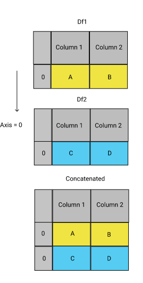

2) Side by Side: Axis = 1

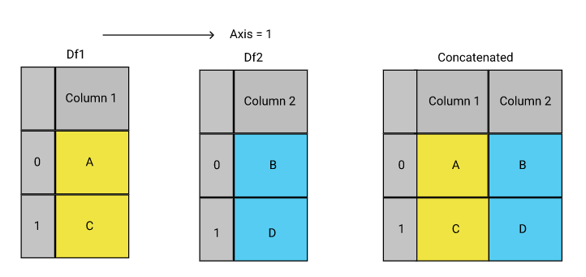

Since concat is a function, not a method, we use the syntax below:

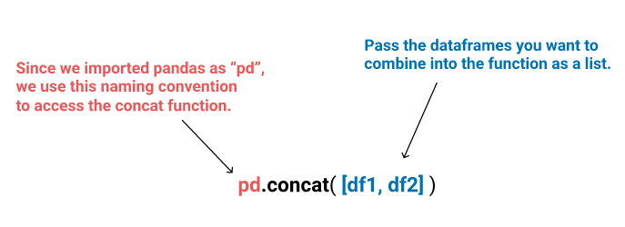

In the next exercise, we'll use the concat() function to combine subsets of happiness2015 and happiness2016 and then debrief the results on the following screen.

Below are the subsets we'll be working with:

```python
head_2015 = happiness2015[['Country','Happiness Score', 'Year']].head(3)
head_2015
```

|  | Country | Happiness Score | Year |
| --- | --- | --- | --- |
| 0 | Switzerland | 7.587 | 2015 |
| 1 | Iceland | 7.561 | 2015 |
| 2 | Denmark | 7.527 | 2015 |

```python
head_2016 = happiness2016[['Country','Happiness Score', 'Year']].head(3)
head_2016
```

|  | Country | Happiness Score | Year |
| --- | --- | --- | --- |
| 0 | Denmark | 7.526 | 2016 |
| 1 | Switzerland | 7.509 | 2016 |
| 2 | Iceland | 7.501 | 2016 |

Combining:

```python
concat_axis0 = pd.concat([head_2015, head_2016])
concat_axis0
```

|  | Country | Happiness Score | Year |
| --- | --- | --- | --- |
| 0 | Switzerland | 7.587 | 2015 |
| 1 | Iceland | 7.561 | 2015 |
| 2 | Denmark | 7.527 | 2015 |
| 0 | Denmark | 7.526 | 2016 |
| 1 | Switzerland | 7.509 | 2016 |
| 2 | Iceland | 7.501 | 2016 |

```python
concat_axis1 = pd.concat([head_2015, head_2016], axis = 1)
concat_axis1
```

|  | Country | Happiness Score | Year | Country | Happiness Score | Year |
| --- | --- | --- | --- | --- | --- | --- |
| 0 | Switzerland | 7.587 | 2015 | Denmark | 7.526 | 2016 |
| 1 | Iceland | 7.561 | 2015 | Switzerland | 7.509 | 2016 |
| 2 | Denmark | 7.527 | 2015 | Iceland | 7.501 | 2016 |

When you reviewed the results from the last exercise, you probably noticed that we merely pushed the dataframes together vertically or horizontally - none of the values, column names, or indexes changed. For this reason, when you use the concat() function to combine dataframes with the same shape and index, you can think of the function as "gluing" dataframes together.

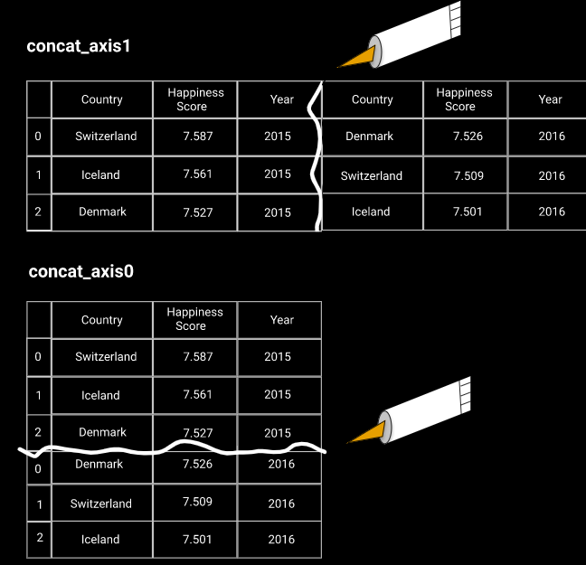

However, what happens if the dataframes have different shapes or columns? Let's confirm the concat() function's behavior when we combine dataframes that don't have the same shape in the next exercise.

We'll work with the following subsets:

```python
head_2015 = happiness2015[['Year','Country','Happiness Score', 'Standard Error']].head(4)
head_2015
```

|  | Year | Country | Happiness Score | Standard Error |
| --- | --- | --- | --- | --- |
| 0 | 2015 | Switzerland | 7.587 | 0.03411 |
| 1 | 2015 | Iceland | 7.561 | 0.04884 |
| 2 | 2015 | Denmark | 7.527 | 0.03328 |
| 3 | 2015 | Norway | 7.522 | 0.03880 |

```python
head_2016 = happiness2016[['Country','Happiness Score', 'Year']].head(3)
head_2016
```

|  | Country | Happiness Score | Year |
| --- | --- | --- | --- |
| 0 | Denmark | 7.526 | 2016 |
| 1 | Switzerland | 7.509 | 2016 |
| 2 | Iceland | 7.501 | 2016 |

Combining them..

```python
concat_axis0 = pd.concat([head_2015, head_2016])
concat_axis0
```

|  | Year | Country | Happiness Score | Standard Error |
| --- | --- | --- | --- | --- |
| 0 | 2015 | Switzerland | 7.587 | 0.03411 |
| 1 | 2015 | Iceland | 7.561 | 0.04884 |
| 2 | 2015 | Denmark | 7.527 | 0.03328 |
| 3 | 2015 | Norway | 7.522 | 0.03880 |
| 0 | 2016 | Denmark | 7.526 | NaN |
| 1 | 2016 | Switzerland | 7.509 | NaN |
| 2 | 2016 | Iceland | 7.501 | NaN |

```python
concat_axis1 = pd.concat([head_2015, head_2016], axis = 1)
concat_axis1
```

|  | Year | Country | Happiness Score | Standard Error | Country | Happiness Score | Year |
| --- | --- | --- | --- | --- | --- | --- | --- |
| 0 | 2015 | Switzerland | 7.587 | 0.03411 | Denmark | 7.526 | 2016.0 |
| 1 | 2015 | Iceland | 7.561 | 0.04884 | Switzerland | 7.509 | 2016.0 |
| 2 | 2015 | Denmark | 7.527 | 0.03328 | Iceland | 7.501 | 2016.0 |
| 3 | 2015 | Norway | 7.522 | 0.03880 | NaN | NaN | NaN |

### Combining dataframes with different shapes using the concat function.

In the last exercise, we saw that the analogy of "gluing" dataframes together doesn't fully describe what happens when concatenating dataframes of different shapes. Instead, the function combined the data according to the corresponding column names:

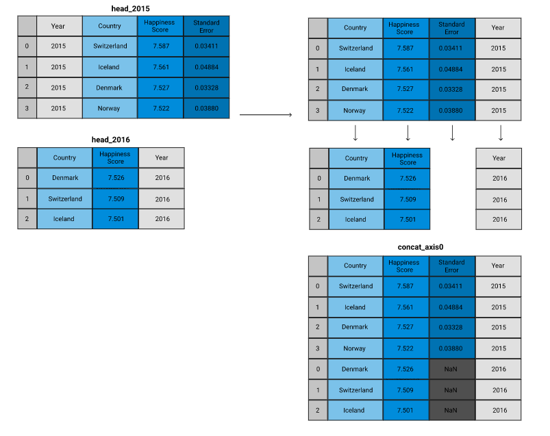

**By default, the concat function will keep ALL of the data, no matter if missing values are created.**

Also, notice again the indexes of the original dataframes didn't change. If the indexes aren't meaningful, it can be better to reset them. This is especially true when we create duplicate indexes, because they could cause errors as we perform other data cleaning tasks.

Luckily, the concat function has a parameter, ignore_index, that can be used to clear the existing index and reset it in the result.

```python
head_2015 = happiness2015[['Year','Country','Happiness Score', 'Standard Error']].head(4)
head_2016 = happiness2016[['Country','Happiness Score', 'Year']].head(3)

concat_update_index = pd.concat([head_2015, head_2016], ignore_index = True)
concat_update_index
```

|  | Year | Country | Happiness Score | Standard Error |
| --- | --- | --- | --- | --- |
| 0 | 2015 | Switzerland | 7.587 | 0.03411 |
| 1 | 2015 | Iceland | 7.561 | 0.04884 |
| 2 | 2015 | Denmark | 7.527 | 0.03328 |
| 3 | 2015 | Norway | 7.522 | 0.03880 |
| 4 | 2016 | Denmark | 7.526 | NaN |
| 5 | 2016 | Switzerland | 7.509 | NaN |
| 6 | 2016 | Iceland | 7.501 | NaN |

## Joining dataframes with the Merge function

Next, we'll explore the `pd.merge()` function - a function that can execute high performance database-style joins. Note that unlike the concat function, the merge function only combines dataframes horizontally (`axis=1`) and can only combine two dataframes at a time. However, it can be valuable when we need to combine very large dataframes quickly and provides more flexibility in terms of how data can be combined, as we'll see in the next couple screens.

With the `merge()` function, we'll combine dataframes on a key, a shared index or column. When choosing a key, it's good practice to use keys with unique values to avoid duplicating data.

You can think of keys as creating a link from one dataframe to another using the common values or indexes. For example, in the diagram below, we linked the dataframes using common values in the Country columns.

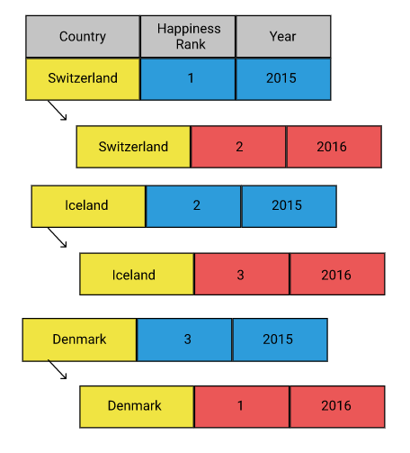

In the diagram below, we use those common country values to join or merge the dataframes.

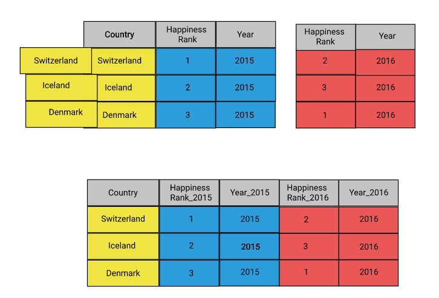

We'll explore the merge function in the next exercise using just three rows from happiness2015 and happiness2016:

```python
happiness2015[['Country','Happiness Rank','Year']].iloc[2:5]
```

|  | Country | Happiness Rank | Year |
| --- | --- | --- | --- |
| 2 | Denmark | 3 | 2015 |
| 3 | Norway | 4 | 2015 |
| 4 | Canada | 5 | 2015 |

```python
happiness2016[['Country','Happiness Rank','Year']].iloc[2:5]
```

|  | Country | Happiness Rank | Year |
| --- | --- | --- | --- |
| 2 | Iceland | 3 | 2016 |
| 3 | Norway | 4 | 2016 |
| 4 | Finland | 5 | 2016 |

We'll use the following syntax:

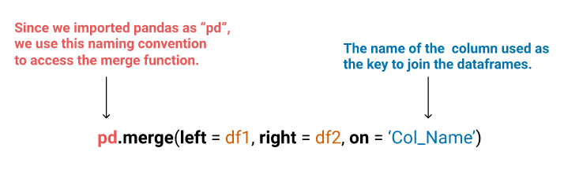

```python
three_2015 = happiness2015[['Country','Happiness Rank','Year']].iloc[2:5]
three_2016 = happiness2016[['Country','Happiness Rank','Year']].iloc[2:5]

merged = pd.merge(left = three_2015, right = three_2016, on = 'Country')
merged
```

|  | Country | Happiness Rank_x | Year_x | Happiness Rank_y | Year_y |
| --- | --- | --- | --- | --- | --- |
| 0 | Norway | 4 | 2015 | 4 | 2016 |

Joining three_2015 and three_2016 in the last exercise resulted in a dataframe with just one row.

Since we joined the dataframes on the Country column, or used it as the key, the merge() function looked to match elements in the Country column in BOTH dataframes.

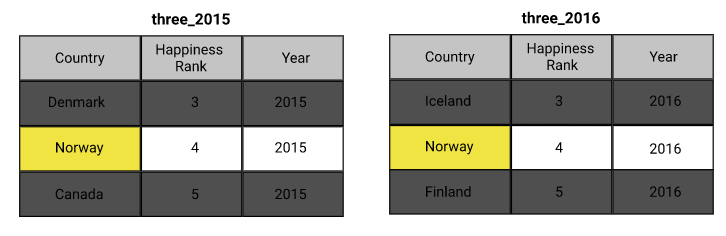

The one country returned in merged was `"Norway"`, the only element that appeared in the Country column in **BOTH** `three_2015` and `three_2016`.

This way of combining, or joining, data is called an **inner join**. An inner join returns only the intersection of the keys, or the elements that appear in both dataframes with a common key.

The term "join" originates from SQL (or structured query language), a language used to work with databases. If you're a SQL user, you'll recognize the following concepts. If you've never used SQL, don't worry! No prior knowledge is neccessary for this mission, but we will learn SQL later in this path.

There are actually four different types of joins:

- **Inner**: only includes elements that appear in both dataframes with a common key
- **Outer**: includes all data from both dataframes
- **Left**: includes all of the rows from the "left" dataframe along with any rows from the "right" dataframe with a common key; the result retains all columns from both of the original dataframes
- **Right**: includes all of the rows from the "right" dataframe along with any rows from the "left" dataframe with a common key; the result retains all columns from both of the original dataframes

If the definition for outer joins sounds familiar, it's because we've already seen examples of outer joins! Recall that when we combined data using the concat function, it kept all of the data from all dataframes, no matter if missing values were created.

Since it's much more common to use inner and left joins for database-style joins, we'll focus on these join types for the remainder of the mission, but encourage you to explore the other options on your own.

```python
merged = pd.merge(left=three_2015, right=three_2016, on='Country')
merged
```

|  | Country | Happiness Rank_x | Year_x | Happiness Rank_y | Year_y |
| --- | --- | --- | --- | --- | --- |
| 0 | Norway | 4 | 2015 | 4 | 2016 |

```python
merged_left = pd.merge(left=three_2015, right=three_2016, on='Country',
                      how = 'left')
merged_left
```

|  | Country | Happiness Rank_x | Year_x | Happiness Rank_y | Year_y |
| --- | --- | --- | --- | --- | --- |
| 0 | Denmark | 3 | 2015 | NaN | NaN |
| 1 | Norway | 4 | 2015 | 4.0 | 2016.0 |
| 2 | Canada | 5 | 2015 | NaN | NaN |

```python
merged_left_updated = pd.merge(left=three_2016,
                               right=three_2015,
                               on='Country',
                               how = 'left')
merged_left_updated
```

|  | Country | Happiness Rank_x | Year_x | Happiness Rank_y | Year_y |
| --- | --- | --- | --- | --- | --- |
| 0 | Iceland | 3 | 2016 | NaN | NaN |
| 1 | Norway | 4 | 2016 | 4.0 | 2015.0 |
| 2 | Finland | 5 | 2016 | NaN | NaN |

### Left joins with the merge function

A left join includes all of the rows from the "left" dataframe along with any rows from the "right" dataframe with a common key.

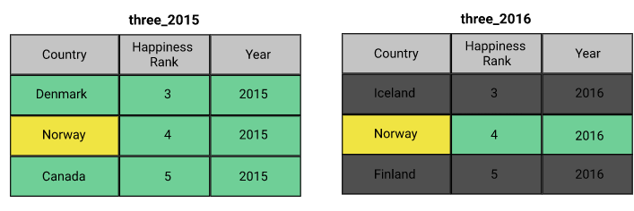

Since the Country column was used as the key, only countries that appear in BOTH dataframes have a value in every column. "Norway" was the only value in the Country column in BOTH dataframes, so it's the only row with a value in every column.

We'd use a left join when we don't want to drop any data from the left dataframe.

Note that a right join works the same as a left join, except it includes all of the rows from the "right" dataframe. Since it's far more common in practice to use a left join, we won't cover right joins in detail.

You may have also noticed above that the merge function added a suffix of either _x or _y to columns of the same name to distinguish between them.

Let's update those suffixes next to make our results easier to read.

```python
merged_updated_suffixes = pd.merge(left=three_2016, right=three_2015, how = 'left',
                          on='Country', suffixes = ('_2016', '_2015'))
merged_updated_suffixes
```

|  | Country | Happiness Rank_2016 | Year_2016 | Happiness Rank_2015 | Year_2015 |
| --- | --- | --- | --- | --- | --- |
| 0 | Iceland | 3 | 2016 | NaN | NaN |
| 1 | Norway | 4 | 2016 | 4.0 | 2015.0 |
| 2 | Finland | 5 | 2016 | NaN | NaN |

### Join on index with the merge function

Now that we have a good understanding of how to join dataframes on specific columns, let's look at another way to join dataframes - on the index.

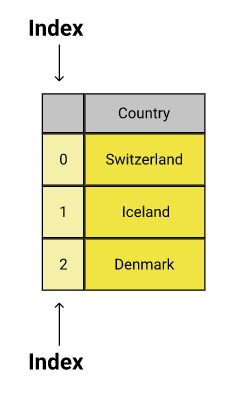

In this screen, we'll work with the following two subsets of happiness2015 and happiness2016:

```python
four_2015 = happiness2015[['Country','Happiness Rank','Year']].iloc[2:6]
four_2015
```

|  | Country | Happiness Rank | Year |
| --- | --- | --- | --- |
| 2 | Denmark | 3 | 2015 |
| 3 | Norway | 4 | 2015 |
| 4 | Canada | 5 | 2015 |
| 5 | Finland | 6 | 2015 |

```python
three_2016 = happiness2016[['Country','Happiness Rank','Year']].iloc[2:5]
three_2016
```

|  | Country | Happiness Rank | Year |
| --- | --- | --- | --- |
| 2 | Iceland | 3 | 2016 |
| 3 | Norway | 4 | 2016 |
| 4 | Finland | 5 | 2016 |

We'll join happiness2015 and happiness2016 on index using an inner join, so that the result contains only the elements in the key that appear in BOTH dataframes.

To join on the index, we'll set the left_index and right_index parameters to `True`:

```python
pd.merge(left=four_2015, right=three_2016, left_index=True, right_index=True, suffixes=('_2015','_2016'))
```

|  | Country_2015 | Happiness Rank_2015 | Year_2015 | Country_2016 | Happiness Rank_2016 | Year_2016 |
| --- | --- | --- | --- | --- | --- | --- |
| 2 | Denmark | 3 | 2015 | Iceland | 3 | 2016 |
| 3 | Norway | 4 | 2015 | Norway | 4 | 2016 |
| 4 | Canada | 5 | 2015 | Finland | 5 | 2016 |

Based on our experience with joining on columns, you may have predicted the output would have just two rows, since only "Finland" and "Norway" appear in both dataframes. When we join on index, however, our result will contain only common indexes.

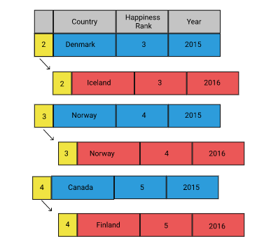

Let's explore what happens when we join on index with a left join instead.

```python
four_2015 = happiness2015[['Country','Happiness Rank','Year']].iloc[2:6]
three_2016 = happiness2016[['Country','Happiness Rank','Year']].iloc[2:5]

merge_index = pd.merge(left = four_2015, right = three_2016, left_index = True,
                       right_index = True, suffixes = ('_2015','_2016'))
merge_index
```

|  | Country_2015 | Happiness Rank_2015 | Year_2015 | Country_2016 | Happiness Rank_2016 | Year_2016 |
| --- | --- | --- | --- | --- | --- | --- |
| 2 | Denmark | 3 | 2015 | Iceland | 3 | 2016 |
| 3 | Norway | 4 | 2015 | Norway | 4 | 2016 |
| 4 | Canada | 5 | 2015 | Finland | 5 | 2016 |

```python
merge_index_left = pd.merge(left = four_2015,right = three_2016, left_index = True,
                            how = 'left',
                            right_index = True,
                            suffixes = ('_2015','_2016'))
merge_index_left
```

|  | Country_2015 | Happiness Rank_2015 | Year_2015 | Country_2016 | Happiness Rank_2016 | Year_2016 |
| --- | --- | --- | --- | --- | --- | --- |
| 2 | Denmark | 3 | 2015 | Iceland | 3.0 | 2016.0 |
| 3 | Norway | 4 | 2015 | Norway | 4.0 | 2016.0 |
| 4 | Canada | 5 | 2015 | Finland | 5.0 | 2016.0 |
| 5 | Finland | 6 | 2015 | NaN | NaN | NaN |

Let's summarize what we learned in this mission:

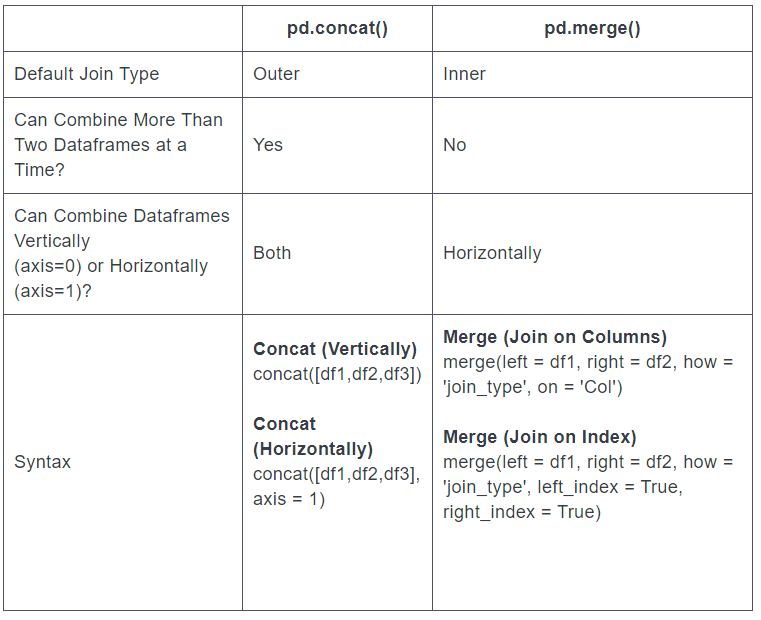

You may still be wondering about when to use each of the functions and methods we've learned. This table can help you understand the limitations of each, but that decision will mostly depend on the problem you're trying to solve.

## Challenge.

#### Did world happiness increase, decrease, or stay about the same from 2015 to 2017?

To answer this question, we'll create a bar plot in which each bar represented the mean happiness score for one of the years. We completed a similar task in the last mission when we calculated the mean happiness score for each region using the df.pivot_table() method:

```python
#Use a pivot table to aggregate the data according to Region.
means = happiness2015.pivot_table('Happiness Score', 'Region', aggfunc=np.mean)
means
```

| Region | Happiness Score |
| --- | --- |
| Australia and New Zealand | 7.285000 |
| Central and Eastern Europe | 5.332931 |
| Eastern Asia | 5.626167 |
| Latin America and Caribbean | 6.144682 |
| Middle East and Northern Africa | 5.406900 |
| North America | 7.273000 |
| Southeastern Asia | 5.317444 |
| Southern Asia | 4.580857 |
| Sub-Saharan Africa | 4.202800 |
| Western Europe | 6.689619 |

Then, we plotted the results with the df.plot() method.

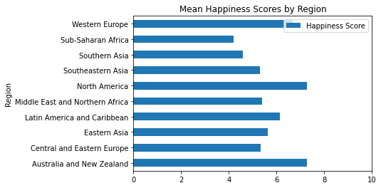

```python
#Use the `df.plot()` method to plot the results.
means.plot(kind='barh', title='Mean Happiness Scores by Region', xlim=(0,10))
```

Let's repeat the same steps, but this time, we'll group the data by the Year column. First, let's rename the Happiness.Score column so it matches the column name in happiness2015 and happiness2016:

```python
happiness2017.rename(columns={'Happiness.Score': 'Happiness Score'}, inplace=True)
happiness2017.head()
```

|  | Country | Happiness.Rank | Happiness Score | Whisker.high | Whisker.low | Economy..GDP.per.Capita. | Family | Health..Life.Expectancy. | Freedom | Generosity | Trust..Government.Corruption. | Dystopia.Residual | Year |
| --- | --- | --- | --- | --- | --- | --- | --- | --- | --- | --- | --- | --- | --- |
| 0 | Norway | 1 | 7.537 | 7.594445 | 7.479556 | 1.616463 | 1.533524 | 0.796667 | 0.635423 | 0.362012 | 0.315964 | 2.277027 | 2017 |
| 1 | Denmark | 2 | 7.522 | 7.581728 | 7.462272 | 1.482383 | 1.551122 | 0.792566 | 0.626007 | 0.355280 | 0.400770 | 2.313707 | 2017 |
| 2 | Iceland | 3 | 7.504 | 7.622030 | 7.385970 | 1.480633 | 1.610574 | 0.833552 | 0.627163 | 0.475540 | 0.153527 | 2.322715 | 2017 |
| 3 | Switzerland | 4 | 7.494 | 7.561772 | 7.426227 | 1.564980 | 1.516912 | 0.858131 | 0.620071 | 0.290549 | 0.367007 | 2.276716 | 2017 |
| 4 | Finland | 5 | 7.469 | 7.527542 | 7.410458 | 1.443572 | 1.540247 | 0.809158 | 0.617951 | 0.245483 | 0.382612 | 2.430182 | 2017 |

Next, we need to combine happiness2015, happiness2016, and happiness2017, so that we can group the result by the Year column.

Let's use what we learned in this mission to combine the dataframes.

```python
combined = pd.concat([happiness2015, happiness2016, happiness2017])
combined
```

|  | Country | Region | Happiness Rank | Happiness Score | Standard Error | Economy (GDP per Capita) | Family | Health (Life Expectancy) | Freedom | Trust (Government Corruption) | ... | Year | Lower Confidence Interval | Upper Confidence Interval | Happiness.Rank | Whisker.high | Whisker.low | Economy..GDP.per.Capita. | Health..Life.Expectancy. | Trust..Government.Corruption. | Dystopia.Residual |
| --- | --- | --- | --- | --- | --- | --- | --- | --- | --- | --- | --- | --- | --- | --- | --- | --- | --- | --- | --- | --- | --- |
| 0 | Switzerland | Western Europe | 1.0 | 7.587 | 0.03411 | 1.39651 | 1.349510 | 0.94143 | 0.665570 | 0.41978 | ... | 2015 | NaN | NaN | NaN | NaN | NaN | NaN | NaN | NaN | NaN |
| 1 | Iceland | Western Europe | 2.0 | 7.561 | 0.04884 | 1.30232 | 1.402230 | 0.94784 | 0.628770 | 0.14145 | ... | 2015 | NaN | NaN | NaN | NaN | NaN | NaN | NaN | NaN | NaN |
| 2 | Denmark | Western Europe | 3.0 | 7.527 | 0.03328 | 1.32548 | 1.360580 | 0.87464 | 0.649380 | 0.48357 | ... | 2015 | NaN | NaN | NaN | NaN | NaN | NaN | NaN | NaN | NaN |
| 3 | Norway | Western Europe | 4.0 | 7.522 | 0.03880 | 1.45900 | 1.330950 | 0.88521 | 0.669730 | 0.36503 | ... | 2015 | NaN | NaN | NaN | NaN | NaN | NaN | NaN | NaN | NaN |
| 4 | Canada | North America | 5.0 | 7.427 | 0.03553 | 1.32629 | 1.322610 | 0.90563 | 0.632970 | 0.32957 | ... | 2015 | NaN | NaN | NaN | NaN | NaN | NaN | NaN | NaN | NaN |
| ... | ... | ... | ... | ... | ... | ... | ... | ... | ... | ... | ... | ... | ... | ... | ... | ... | ... | ... | ... | ... | ... |
| 150 | Rwanda | NaN | NaN | 3.471 | NaN | NaN | 0.945707 | NaN | 0.581844 | NaN | ... | 2017 | NaN | NaN | 151.0 | 3.543030 | 3.398970 | 0.368746 | 0.326425 | 0.455220 | 0.540061 |
| 151 | Syria | NaN | NaN | 3.462 | NaN | NaN | 0.396103 | NaN | 0.081539 | NaN | ... | 2017 | NaN | NaN | 152.0 | 3.663669 | 3.260331 | 0.777153 | 0.500533 | 0.151347 | 1.061574 |
| 152 | Tanzania | NaN | NaN | 3.349 | NaN | NaN | 1.041990 | NaN | 0.390018 | NaN | ... | 2017 | NaN | NaN | 153.0 | 3.461430 | 3.236570 | 0.511136 | 0.364509 | 0.066035 | 0.621130 |
| 153 | Burundi | NaN | NaN | 2.905 | NaN | NaN | 0.629794 | NaN | 0.059901 | NaN | ... | 2017 | NaN | NaN | 154.0 | 3.074690 | 2.735310 | 0.091623 | 0.151611 | 0.084148 | 1.683024 |
| 154 | Central African Republic | NaN | NaN | 2.693 | NaN | NaN | 0.000000 | NaN | 0.270842 | NaN | ... | 2017 | NaN | NaN | 155.0 | 2.864884 | 2.521116 | 0.000000 | 0.018773 | 0.056565 | 2.066005 |

470 rows × 22 columns

```python
#Use a pivot table to aggregate the data according to Region.
means_combined = combined.pivot_table('Happiness Score', 'Year')
means_combined
```

| Year | Happiness Score |
| --- | --- |
| 2015 | 5.375734 |
| 2016 | 5.382185 |
| 2017 | 5.354019 |

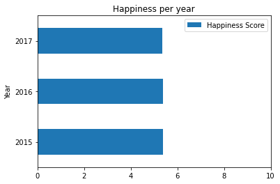

```python
means_combined.plot(kind = 'barh', title='Happiness per year', xlim = (0, 10))
```

In the last exercise, we confirmed that the mean world happiness score stayed approximately the same from 2015 to 2017.

In this mission, we learned how to combine data using the pd.concat() and pd.merge() functions. In your travels with pandas, you may happen upon the df.append() and df.join() methods, which are basically shortcuts for the concat() and merge() functions. We didn't cover them in this mission, as the differences are few, but if you want to learn more about them, check out this documentation.

As we saw in the last screen, in order to perform more complex analysis, we have to be able to clean and manipulate data, whether it be adding data to a dataframe or renaming a column. In the next mission, we'll continue building on what we've learned so far as we learn ways to transform and reshape our data.